# QP1: King County Housing Price Analysis

Eric Hestekin

1/23/2020

Repo: https://github.com/ehestekin/MSBA_5210_DataVis

# 1 Load data and get initial summary

*Uni-variate non-graphical*

```r
#load data and print column names and first few rows
house_data <- read.csv('qp1_data.csv')

head(house_data, 5)
```

```
##    price bedrooms bathrooms sqft_living sqft_lot floors waterfront view
## 1 221900        3      1.00        1180     5650      1          0    0
## 2 538000        3      2.25        2570     7242      2          0    0
## 3 180000        2      1.00         770    10000      1          0    0
## 4 604000        4      3.00        1960     5000      1          0    0
## 5 510000        3      2.00        1680     8080      1          0    0
##   grade condition yr_built yr_renovated zip_code
## 1     7         3     1955            0    98178
## 2     7         3     1951         1991    98125
## 3     6         3     1933            0    98028
## 4     7         5     1965            0    98136
## 5     8         3     1987            0    98074
```

```r
#get stats of basic housing quantitative data
summary(house_data[,1:5])
```

```
##      price            bedrooms        bathrooms      sqft_living
##  Min.   :  75000   Min.   : 0.000   Min.   :0.000   Min.   :  290
##  1st Qu.: 321950   1st Qu.: 3.000   1st Qu.:1.750   1st Qu.: 1427
##  Median : 450000   Median : 3.000   Median :2.250   Median : 1910
##  Mean   : 540182   Mean   : 3.371   Mean   :2.115   Mean   : 2080
##  3rd Qu.: 645000   3rd Qu.: 4.000   3rd Qu.:2.500   3rd Qu.: 2550
##  Max.   :7700000   Max.   :33.000   Max.   :8.000   Max.   :13540
##     sqft_lot
##  Min.   :    520
##  1st Qu.:   5040
##  Median :   7618
##  Mean   :  15107
##  3rd Qu.:  10688
##  Max.   :1651359
```

```r
#categorical data
summary(house_data[,c('view','grade','condition','yr_built')])
```

```
##       view            grade          condition        yr_built
##  Min.   :0.0000   Min.   : 1.000   Min.   :1.000   Min.   :1900
##  1st Qu.:0.0000   1st Qu.: 7.000   1st Qu.:3.000   1st Qu.:1951
##  Median :0.0000   Median : 7.000   Median :3.000   Median :1975
##  Mean   :0.2343   Mean   : 7.657   Mean   :3.409   Mean   :1971
##  3rd Qu.:0.0000   3rd Qu.: 8.000   3rd Qu.:4.000   3rd Qu.:1997
##  Max.   :4.0000   Max.   :13.000   Max.   :5.000   Max.   :2015
```

```r
#waterfront frequency
num_wf <- sum(house_data$waterfront)
num_wf
```

```
## [1] 163
```

```r
#percentage
round(num_wf / nrow(house_data) * 100, 2)
```

```
## [1] 0.75
```

```r
#sort by zip
house_data_by_zip <- house_data %>% group_by(zip_code) %>%
  summarize_all(.funs = mean)

#add count.  couldn't figure out how to do this along with summarize_all
count <- tally(group_by(house_data, zip_code))

house_data_by_zip <- left_join(house_data_by_zip, count, by = "zip_code")

# Get 5 cheapest and most expensive zip codes
house_data_by_zip <- house_data_by_zip %>% arrange(price)

five_cheapest_zips = house_data_by_zip[1:5,'zip_code']
num_zips <- nrow(house_data_by_zip)
five_expense_zips  = house_data_by_zip[(num_zips-4):num_zips,'zip_code']
```

### 1.0.1 Comments

- Large range of house size and price (expected)
  - Right skewed
- Not very many houses have a view. Only upper quarter.
  - Similarly less than 1% are waterfront
- Grade and condition both mostly symmetrically distributed
  - Median value for both is the middle rating. No major bias.
  - Slight right skew. Maybe due to average house being sold is above average condition at time of sale?
- Year is slightly left skewed. Implies many older homes being sold.

### 1.0.2 Questions

- Location (zip code) effect on price for similar size house
- Sqft vs number of bed/bath. Size of yard effect?
  - I think size of yard would be sqft_lot - sqft_house / num_floors
- Effect of year on price as well as renovation year
- Shape of relationship between condition and price

# 2 Uni-variate graphical analysis

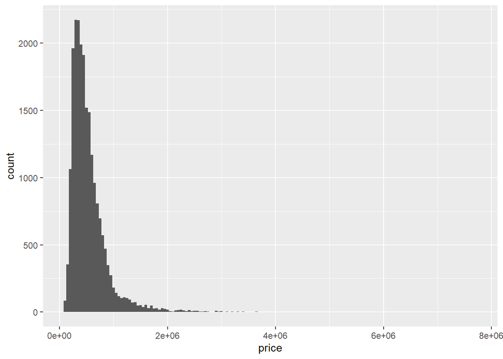

```r
ggplot(house_data, mapping = aes(x = price)) +
  geom_histogram(binwidth = 50000)
```

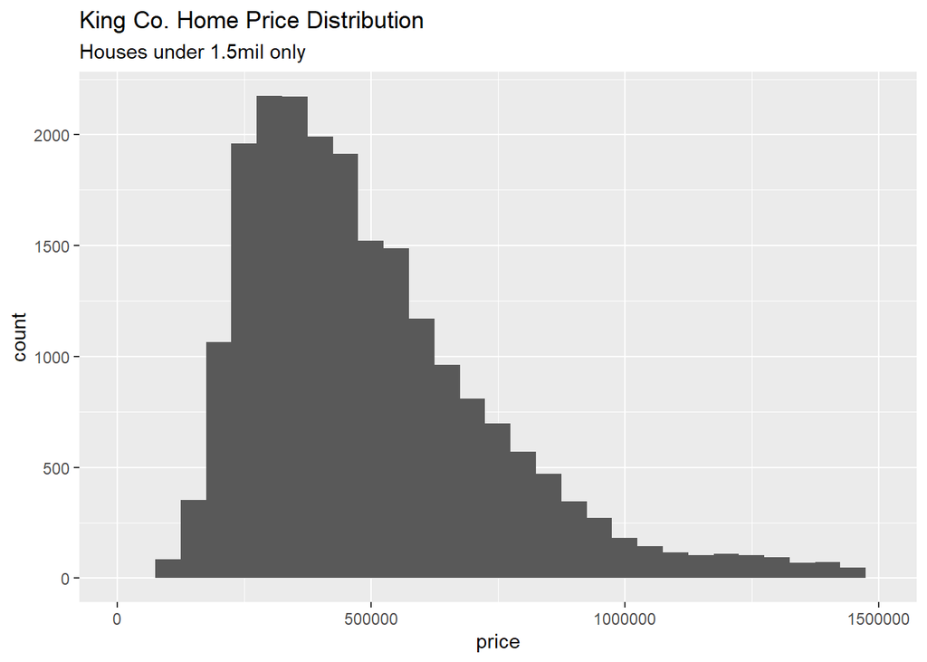

```r
#zoom on houses < 1.5mil
ggplot(house_data, mapping = aes(x = price)) +
  geom_histogram(binwidth = 50000) +
  xlim(0, 1.5e6) +
  ggtitle('King Co. Home Price Distribution', subtitle = 'Houses under 1.5mil only')
```

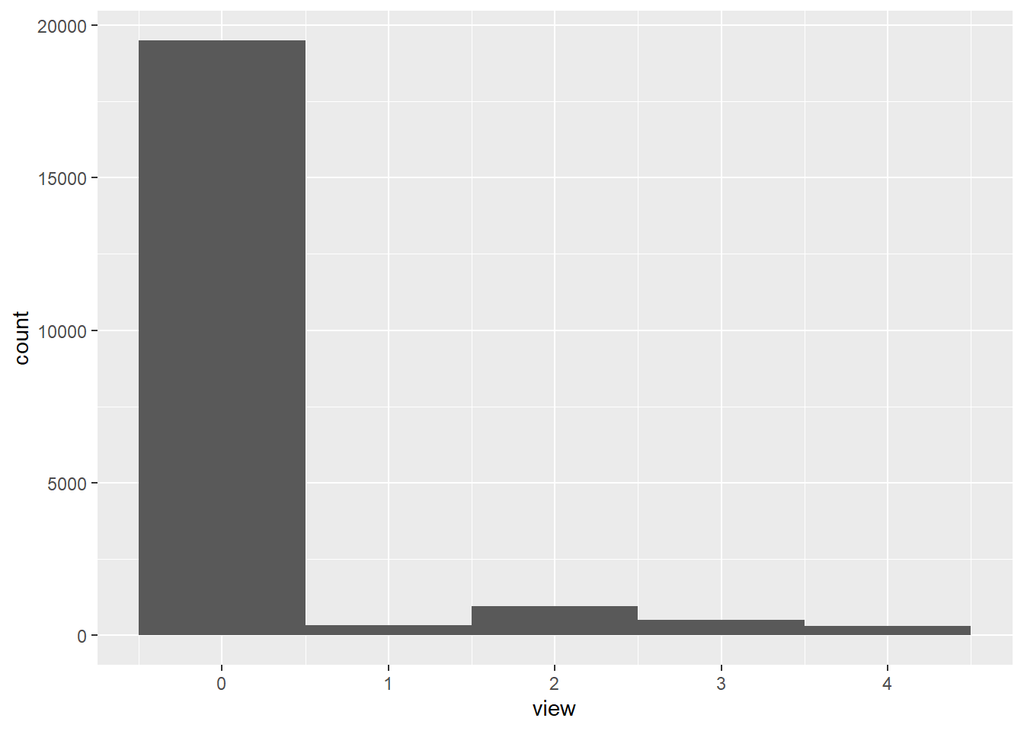

```r
# house with view distro
ggplot(house_data, mapping = aes(x = view)) +
  geom_histogram(binwidth = 1)
```

```r
#count houses with view (similar to waterfront above)
count(house_data, vars = view)
```

```
## # A tibble: 5 x 2
##    vars     n
##   <int> <int>
## 1     0 19489
## 2     1   332
## 3     2   963
## 4     3   510
## 5     4   319
```

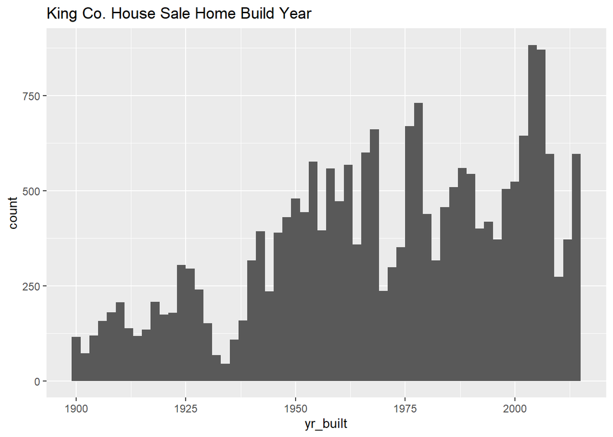

```r
#year built distro
ggplot(house_data, mapping = aes(x = yr_built)) +
  geom_histogram(binwidth = 2) +
  ggtitle('King Co. House Sale Home Build Year')
```

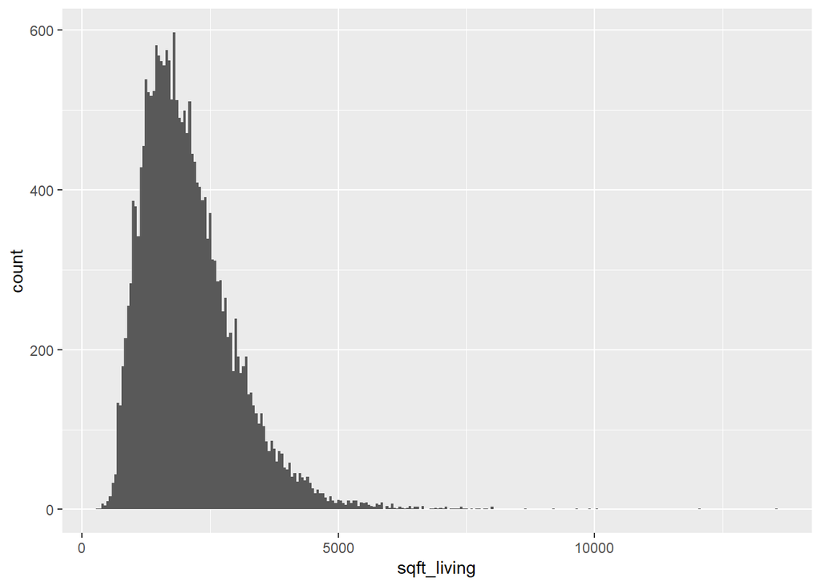

```r
#house and yard sizes
# add yard size variable.  subtract footprint of house
# use floor function on floors (ha) to account for split levels
house_data <- house_data %>% mutate(sqft_yard = sqft_lot - (sqft_living / floor(floors)))

ggplot(house_data, mapping = aes(x = sqft_living)) +
  geom_histogram(binwidth = 50)
```

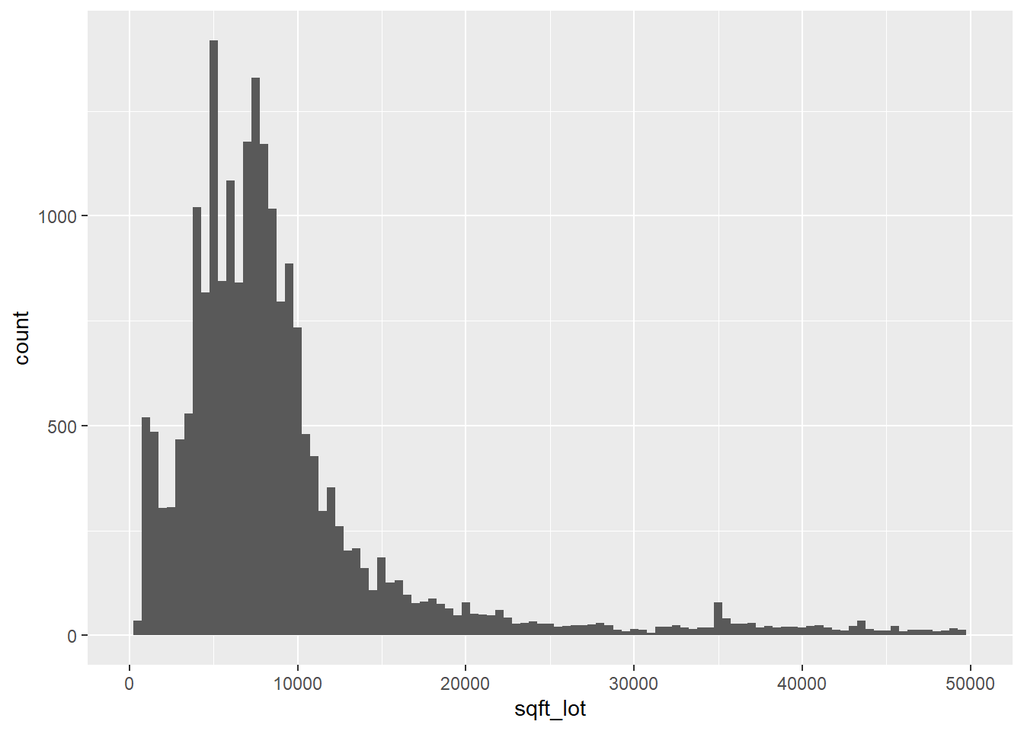

```r
ggplot(house_data, mapping = aes(x = sqft_lot)) +
  geom_histogram(binwidth = 500) +
  xlim(0,5e4)
```

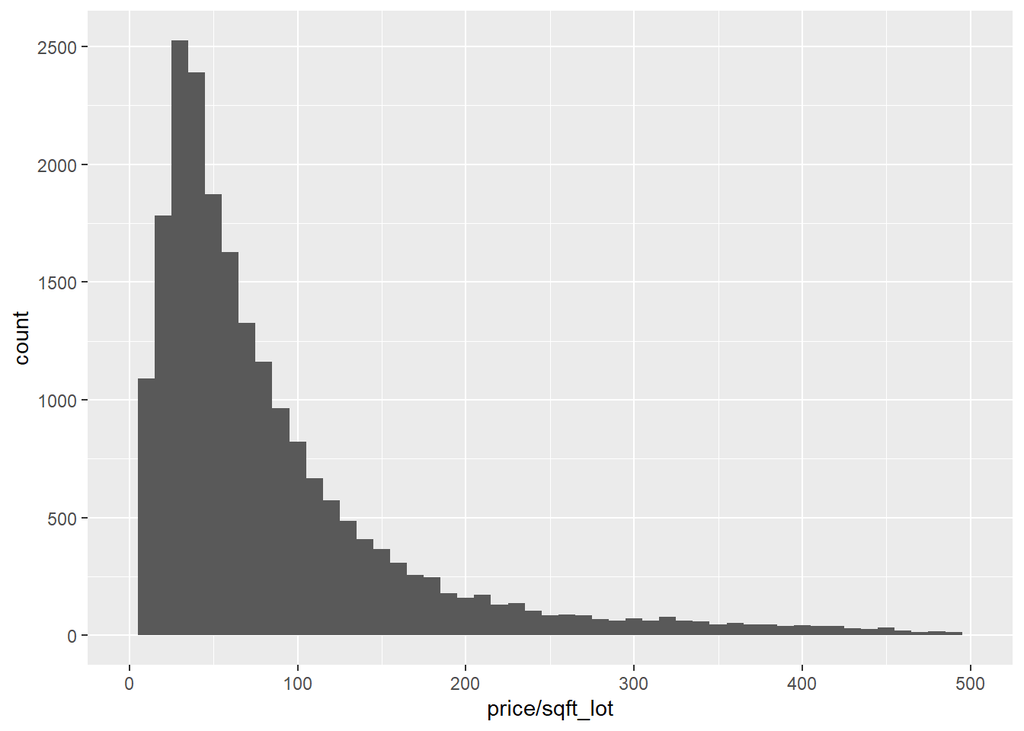

```r
#look at price/sqft lot
ggplot(house_data, mapping = aes(x = price / sqft_lot)) +
  geom_histogram(binwidth = 10) +
  xlim(0,500)
```

### 2.0.2 Questions

- How closely related are price and square footage?
- Impact of rare view or waterfront on price
- Impact of age of home and how much remodel effects

# 3 Non Graphical Multivariate Analysis

```r
# first test correlations of price with various factors

house_data %>% select(price,sqft_living, sqft_lot) %>%
  cor() %>% round(3) %>% kable()
```

|  | price | sqft_living | sqft_lot |
| --- | --- | --- | --- |
| price | 1.000 | 0.702 | 0.090 |
| sqft_living | 0.702 | 1.000 | 0.173 |
| sqft_lot | 0.090 | 0.173 | 1.000 |

```r
house_data %>% select(price, sqft_living, yr_built) %>%
  cor() %>% round(3) %>% kable()
```

|  | price | sqft_living | yr_built |
| --- | --- | --- | --- |
| price | 1.000 | 0.702 | 0.054 |
| sqft_living | 0.702 | 1.000 | 0.318 |
| yr_built | 0.054 | 0.318 | 1.000 |

```r
# condition vs age
house_data %>% select(yr_built, condition) %>%
  cor() %>% round(3) %>% kable()
```

|  | yr_built | condition |
| --- | --- | --- |
| yr_built | 1.000 | -0.361 |
| condition | -0.361 | 1.000 |

### 3.0.1 Comments

- Strong correlation between price and living sq ft
  - Not much of a correlation for lot size
- Age and price not directly correlated.
  - Age and square footage have a stronger correlation.
    - Implies houses have been getting bigger as time goes on
- Negative correlation between condition and year which makes sense
  - Same as a positve correlation between *age* and condition

# 4 Multivariate Graphical Analysis

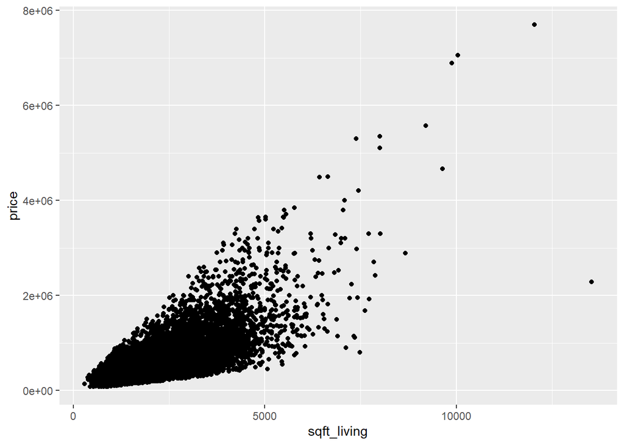

```r
# continue looking into correlated variables
ggplot(house_data, mapping = aes(sqft_living, price)) +
  geom_point()
```

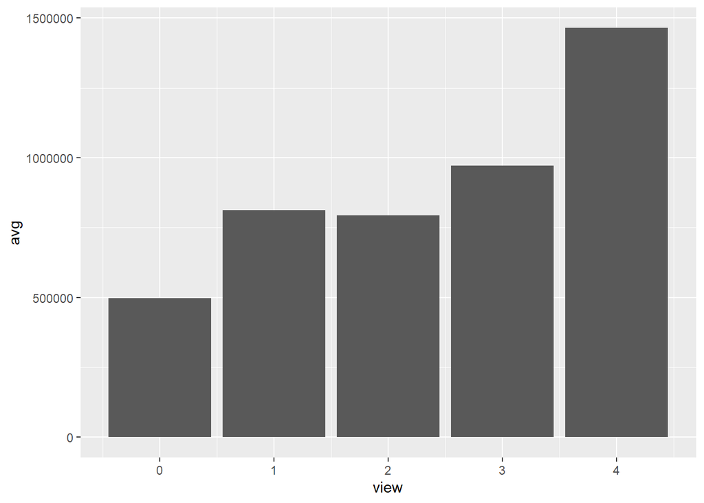

```r
#effect of view
view_group <- house_data %>% group_by(view) %>% summarize(avg = mean(price))

ggplot(view_group, mapping = aes(x = view, y = avg)) +
  geom_bar(stat = 'identity')
```

[output not shown]

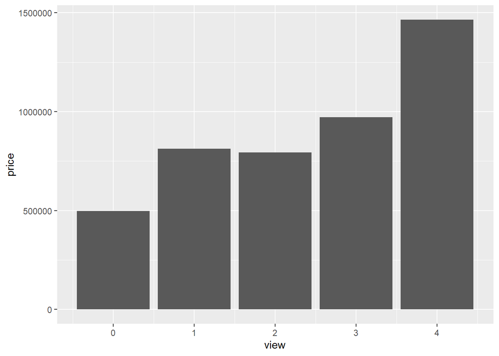

```r
#cool alternate way without doing group_by into a new df
ggplot(house_data, mapping = aes(x = view, y  = price)) +
  geom_bar(stat = 'summary')
```

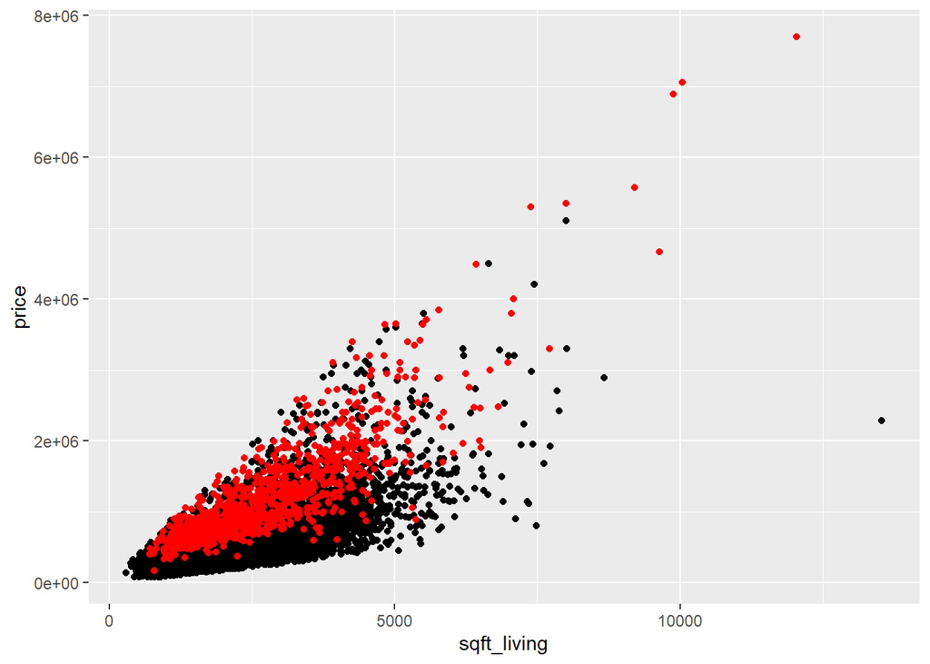

```r
#plot price per sqft and add color for most expensive and least expensive zips
#first make subset of data
house_data_5_expense_zips <- house_data[house_data$zip_code %in% five_expense_zips$zip_code,]
ggplot(house_data,mapping = aes(sqft_living, price)) +
  geom_point() +
  geom_point(house_data_5_expense_zips, mapping = aes(sqft_living, price),color = 'red')
```

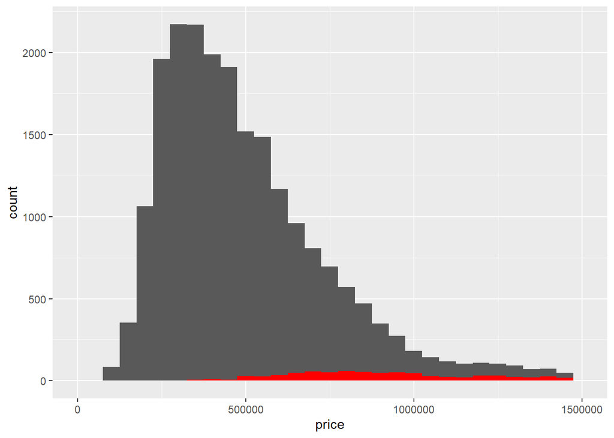

```r
#try similar idea with histogram
ggplot(house_data, mapping = aes(x = price)) +
  geom_histogram(binwidth = 50000) +
  xlim(0, 1.5e6) +
  geom_histogram(data = house_data_5_expense_zips, mapping = aes(price)
                 , fill = 'red', binwidth = 50000)
```

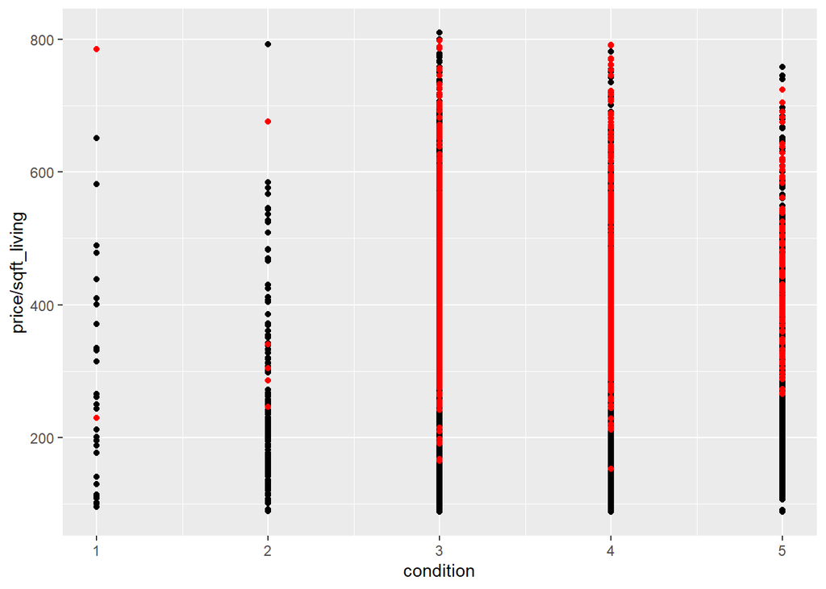

```r
#would need to normalize above plot because it is hard to see.  good idea for later

#condition vs price
ggplot(house_data, mapping = aes(x = condition, y = price / sqft_living)) +
  geom_point() +
  geom_point(house_data_5_expense_zips, mapping = aes(x = condition, y = price / sqft_living), color = 'red')
```

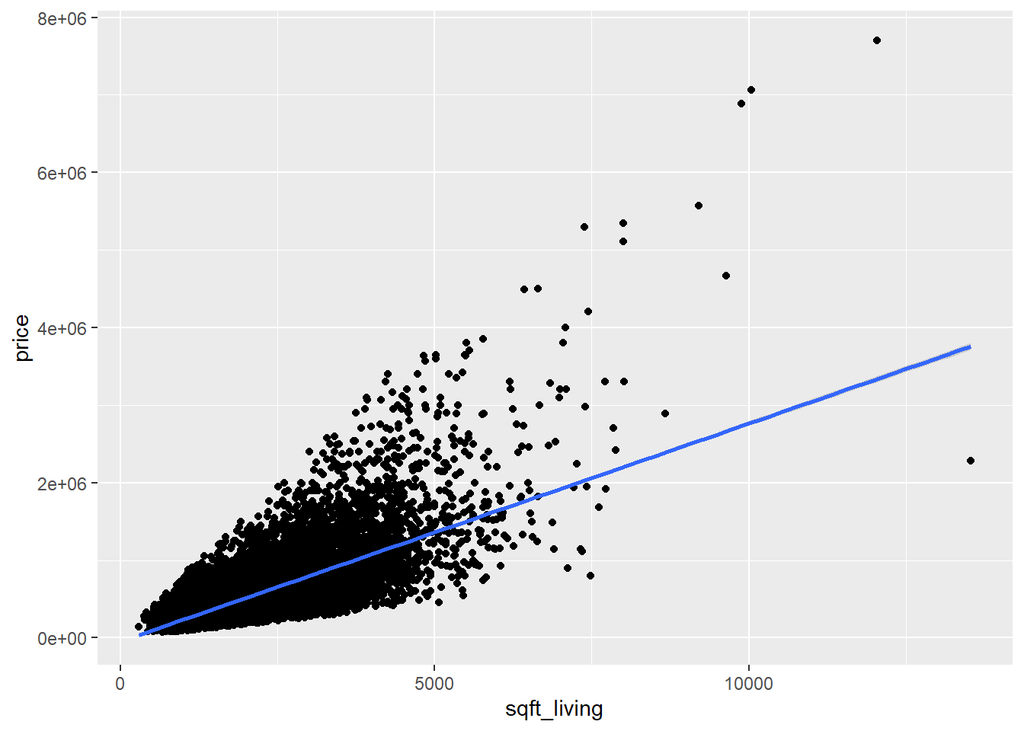

```r
ggplot(house_data, mapping = aes(sqft_living, price)) +
  geom_point() +
  geom_smooth(method = 'lm')#do smooth for each condition, see if slopes are same
```

# 5 Refine Plots

```
## No summary function supplied, defaulting to `mean_se()
```

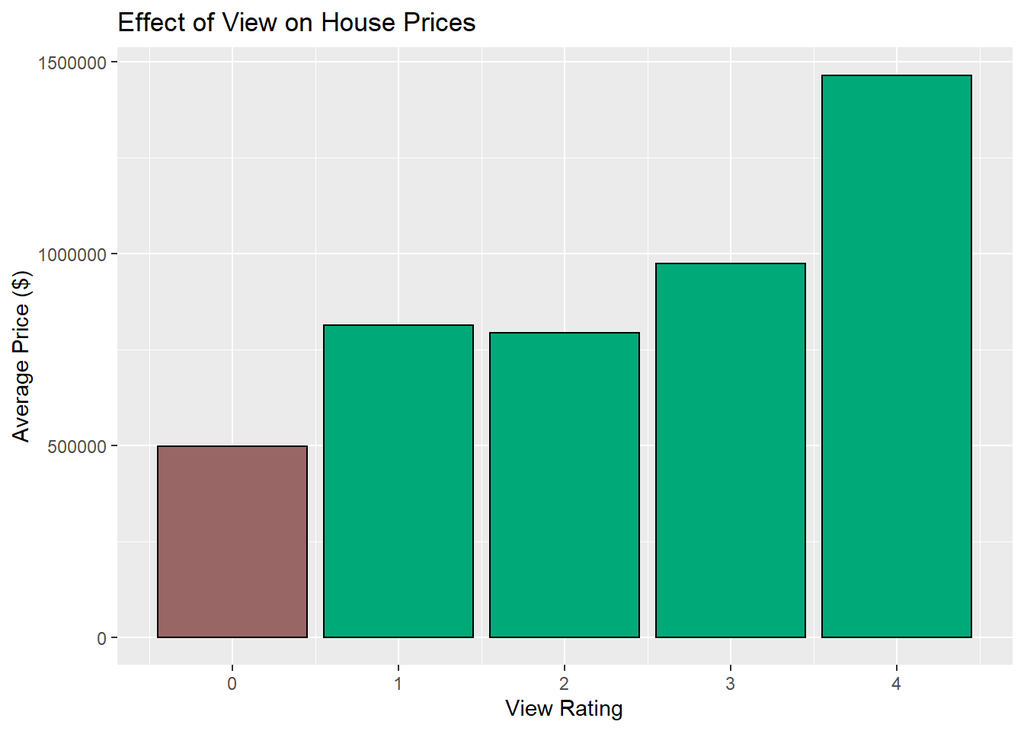

```r
# view vs price

ggplot(house_data, mapping = aes(x = view, y  = price)) +
  geom_bar(stat = 'summary', color = 'black', fill = c('#996666','#00aa78','#00aa78','#00aa78','#00aa78')) +
  xlab('View Rating') +
  ggtitle('Effect of View on House Prices') +
  ylab('Average Price ($)')
```

```r
ggsave(filename = 'view_vs_price.png', plot = last_plot())
```

```
## No summary function supplied, defaulting to `mean_se()
```

```
## No summary function supplied, defaulting to `mean_se()
```

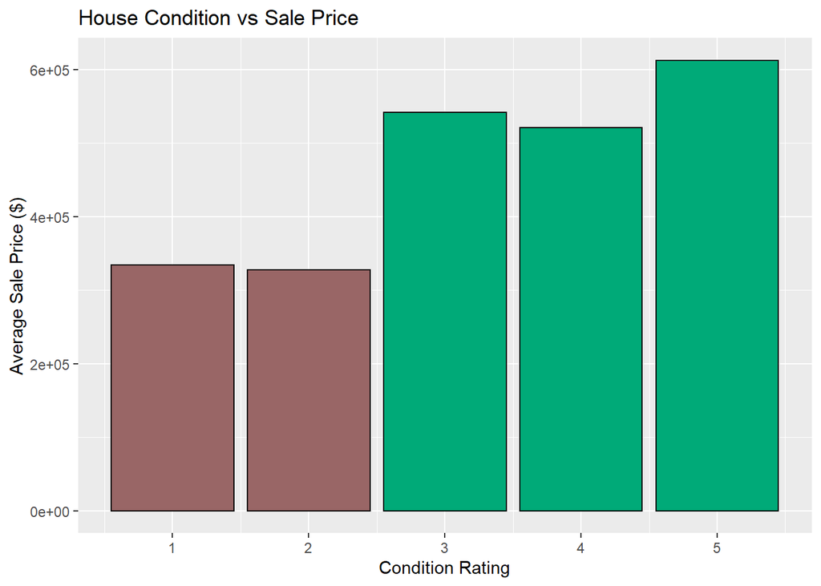

```r
# effect of age and renovations
p_age <- ggplot(house_data, mapping = aes(x = yr_built, y = price / sqft_living)) +
          geom_point(alpha = 0.1) +
          ggtitle('King Co. Home Build Year vs Price per SqFt') +
          xlab('Home Build Year') +
          ylab('Price per SqFt ($)')

#add regression for year and rennovation
build_yr_lm <- lm(price / sqft_living ~ yr_built, data = house_data)
renov_only_data <- house_data %>% filter(yr_renovated > 0)
renov_lm <- lm(price / sqft_living ~ yr_renovated, data = renov_only_data)

#p_age <- p_age + geom_abline(slope = build_yr_lm$coefficients[2], intercept = build_yr_lm$coefficients[1], col = '#0000cc')

#look at rennovation year with condition
p_age <-  p_age + geom_abline(slope = renov_lm$coefficients[2], intercept = renov_lm$coefficients[1], col = '#cc0000')

ggsave(filename = 'price_vs_yr_built.png', plot = p_age)
# condition
ggplot(house_data, mapping = aes(x= condition, y = price)) +
  geom_bar(stat = 'summary', color = 'black', fill = c('#996666','#996666','#00aa78','#00aa78','#00aa78')) +
  xlab('Condition Rating') +
  ylab('Average Sale Price ($)') +
  ggtitle('House Condition vs Sale Price')
```

```r
  ggsave(filename = 'condition_vs_price.png', plot = last_plot())
```

```
## No summary function supplied, defaulting to `mean_se()
```